# Machine Learning For Signal Processing (ENGR-E 511) Homework 2 , Spring 2022

**Name: Anitha Ganapathy**  
**Email: aganapa@iu.edu**

## **P1: De-beeper [5 points]**

Organizing the imports

```python
# Import the necessary libraries

from PIL import Image
import numpy as np
import pandas as pd
import matplotlib.pyplot as plt
# import matplotlib.mlab as mlab
import librosa
import soundfile as sf
from IPython.display import Audio
import cmath, math
import scipy.io  # to read .mat files
import seaborn as sns

from google.colab import drive

drive.mount('/content/drive')
```

```python
dirpath = '/content/drive/MyDrive/MLSP_data/'
!ls $dirpath
```

```
'Cleaned Output.wav'	 december.mat  'HW_1 data'   june.png
'De Beeped Output.wav'	 december.png   june.mat     x.wav
```

Loading file using librosa

https://librosa.org/doc/main/generated/librosa.load.html

```python
# Load the x.wav file using librosa

filename= dirpath + 'x.wav'
x, sr = librosa.load(filename , sr = None)
```

```python
len(x) , sr
```

```
(63488, 16000)
```

```python
# https://stackoverflow.com/questions/9777783/suppress-scientific-notation-in-numpy-when-creating-array-from-nested-list

np.set_printoptions(suppress=True)
x[:10]
```

```
array([ 0.01422119,  0.0201416 ,  0.01419067,  0.00006104, -0.01412964,
       -0.0199585 , -0.0140686 ,  0.00003052,  0.01419067,  0.02005005],
      dtype=float32)
```

### Displaying the signal in time and frequency domain before processing.

https://pythontic.com/visualization/signals/spectrogram

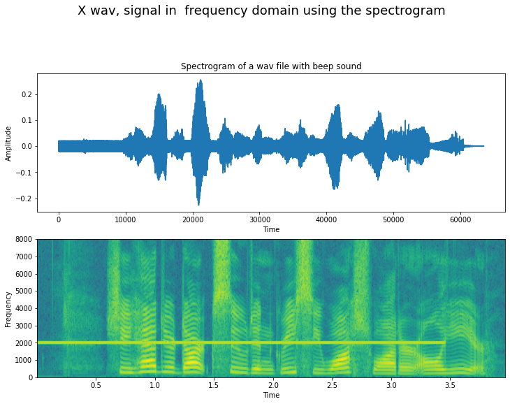

```python
# Plot the signal read from wav file

plt.figure(figsize = (12,8))
plt.subplot(211)
plt.title('Spectrogram of a wav file with beep sound')
plt.suptitle("X wav, signal in time domain ", y=1.05, fontsize=18)
plt.plot(x)
plt.xlabel('Time')
plt.ylabel('Amplitude')

plt.subplot(212)
plt.specgram(x ,Fs = sr)
plt.suptitle("X wav, signal in  frequency domain using the spectrogram ", y=1.05, fontsize=18)
plt.xlabel('Time')
plt.ylabel('Frequency')
plt.show()
```

```python
print('Original x.wav with the beep signal ')
Audio(x, rate = sr)
```

```
Original x.wav with the beep signal
```

[interactive chart not shown]

### Processing for de-beeper begins

DFT matrix generation

```python
print("Sampling rate used while loading the signal :", sr)
```

```
Sampling rate used while loading the signal : 16000
```

```python
from scipy import fft
```

```python
np.exp(1j)
```

```
(0.5403023058681398+0.8414709848078965j)
```

- Complex numbers in python : https://stackoverflow.com/questions/8370637/complex-numbers-in-python
- cmath — Mathematical functions for complex numbers : https://docs.python.org/3/library/cmath.html

```python
print(np.sqrt(1j))
print(cmath.sqrt(1j))
```

```
(0.7071067811865476+0.7071067811865476j)
(0.7071067811865476+0.7071067811865475j)
```

**Create a DFT matrix F using the first equation in M02-S12**

$$ X[f]=\sum_{n=0}^{N-1} x[n] \exp \left\{-j\left(2 \pi f \frac{n}{N}\right)\right\} $$

https://stackoverflow.com/questions/62785140/coding-a-discrete-fourier-transform-on-python-without-using-built-in-functions

```python
# since the signal’s sampling rate is 16kHz, if your N is 1600, your frequency resolution (the range a Fourier coefficient covers) will be 10Hz. If

def DTF_matrix(N):
  dft_mat = np.array([[np.exp(-1j * (2 * np.pi * f * n / N)) for f in range(0, N)] for n in range(0, N)])
  return dft_mat
```

```python
N = 1600
dft_matrix = DTF_matrix(N)
```

```python
print(dft_matrix.shape)
dft_matrix[:5, :5]
```

```
(1600, 1600)
```

```
array([[1.        -0.j        , 1.        -0.j        ,
        1.        -0.j        , 1.        -0.j        ,
        1.        -0.j        ],
       [1.        -0.j        , 0.99999229-0.00392698j,
        0.99996916-0.0078539j , 0.99993061-0.0117807j ,
        0.99987663-0.01570732j],
       [1.        -0.j        , 0.99996916-0.0078539j ,
        0.99987663-0.01570732j, 0.99972243-0.02355976j,
        0.99950656-0.03141076j],
       [1.        -0.j        , 0.99993061-0.0117807j ,
        0.99972243-0.02355976j, 0.9993755 -0.03533556j,
        0.99888987-0.04710645j],
       [1.        -0.j        , 0.99987663-0.01570732j,
        0.99950656-0.03141076j, 0.99888987-0.04710645j,
        0.99802673-0.06279052j]])
```

```python
# plt.figure(figsize=(4,4))

# w = np.exp(-1j *2 * np.pi /N)
# J, K = np.meshgrid(np.arange(N), np.arange(N))
# DFT = np.power(w, J*K)
# DFT = np.real(DFT)
# plt.imshow(DFT)
# plt.show()
```

### Data Matrix **X** preparation

**Hann and Hamming windows**
Hann function:
The customary cosine-sum windows for case $K=1$ have the form: $$ w[n]=a_{0}-\underbrace{\left(1-a_{0}\right)}_{a_{1}} \cdot \cos \left(\frac{2 \pi n}{N}\right), \quad 0 \leq n \leq N $$ which is easily (and often) confused with its zero-phase version: $$ \begin{aligned} w_{0}(n) &=w\left[n+\frac{N}{2}\right] \\ &=a_{0}+a_{1} \cdot \cos \left(\frac{2 \pi n}{N}\right), \quad-\frac{N}{2} \leq n \leq \frac{N}{2} \end{aligned} $$ Setting $a_{0}=0.5$ produces a Hann window: $$ w[n]=0.5\left[1-\cos \left(\frac{2 \pi n}{N}\right)\right]=\sin ^{2}\left(\frac{\pi n}{N}\right) $$

**Numpy version of Hann window**  
https://numpy.org/doc/stable/reference/generated/numpy.hanning.html

The Hanning window is defined as $$ w(n)=0.5-0.5 \cos \left(\frac{2 \pi n}{M-1}\right) \quad 0 \leq n \leq M-1 $$

```python
def data_matrix_prep(in_data, N):
    hann_win = np.hanning(N)
    window_counts = int(in_data.shape[0]/N)  #  cos 63488 is not even multiple of N(1600)
    new_data_mat_len = N * window_counts
    new_data = []
    count = 0
    # print(new_data_mat_len)

    for i in range(0, new_data_mat_len  , int(N/2)):
        data_window = np.multiply(in_data[i : i + N], hann_win)
        # print(f'{i} \t {i+N}')
        count +=1
        new_data.append(data_window)

    print("Total num of columns :", count)

    # Place it as your first column vector of the data matrix X
    # Transpose the matrix to convert the row vectors to column vectors
    new_data_matrix = np.array(new_data).T

    return new_data_matrix
```

```python
X_mat = data_matrix_prep(x, N)
print(X_mat.shape)
```

```
Total num of columns : 78
(1600, 78)
```

**Apply the DFT matrix from P1.2 to your data matrix, i.e., FX**

```python
spectrogram_x_original = np.dot(dft_matrix, X_mat)
spectrogram_x_original_mag = np.abs(spectrogram_x_original)
spectrogram_x_original.shape
```

```
(1600, 78)
```

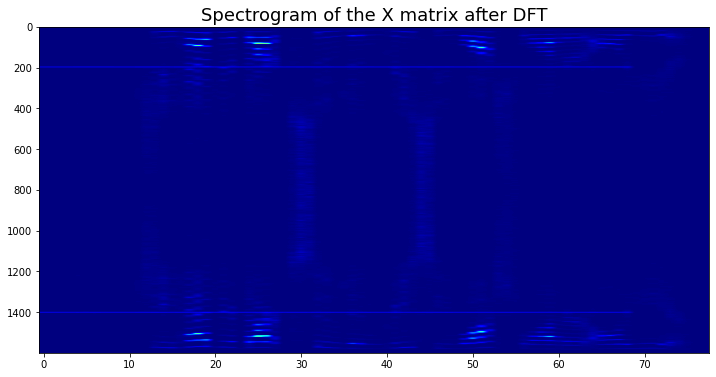

```python
plt.figure(figsize= (12,6))
plt.title("Spectrogram of the X matrix after DFT", fontsize=18)
plt.imshow(spectrogram_x_original_mag, cmap='jet', aspect='auto')
plt.show()

# plt.figure(figsize = (12,5))
# plt.title("DFT of X wav, signal in time domain ", fontsize=18)
# plt.plot(spectrogram_x_original)
# plt.xlabel('DFT of x wave')
# plt.ylabel('Amplitude')
# plt.show()
```

Locate two thin horizontal lines. They are from the beep sound. Note that due to the conjugacy your spectrogram is mirrored vertically.

**From the above spectrogram we can easily visualize the two horizontal lines which represents the beep noise**

**Apply the inverse DFT matrix, which you can also create by using the equation in M2 S12**

```python
indeces = [199, 200, 201, 1399, 1400, 1401]   # to be safer we try to flatten the surrounding magnitudes as well.
spectrogram_x_original_debeeped = np.copy(spectrogram_x_original)
spectrogram_x_original_debeeped[indeces] = 0
```

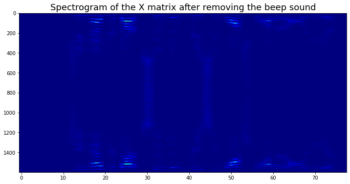

```python
plt.figure(figsize= (12,6))
plt.title("Spectrogram of the X matrix after removing the beep sound", fontsize=18)
plt.imshow(np.abs(spectrogram_x_original_debeeped), cmap='jet', aspect='auto')
plt.show()
```

### Applying IIFT

```python
def idft_matrix(m_size):

    idft_matrix = np.array([[np.exp(1j * (2 * np.pi * f * n /m_size)) for f in range(0,m_size)] for n in range(0,m_size)])/m_size
    return idft_matrix

idft_mat = idft_matrix(1600)

print('The shape of the idft matrix is: ' , idft_mat.shape)
```

```
The shape of the idft matrix is:  (1600, 1600)
```

```python
fstar_f = np.dot(idft_mat, dft_matrix)
print('We can see that F*F is an identity matrix: \n', np.abs(fstar_f.real))
```

```
We can see that F*F is an identity matrix:
 [[1. 0. 0. ... 0. 0. 0.]
 [0. 1. 0. ... 0. 0. 0.]
 [0. 0. 1. ... 0. 0. 0.]
 ...
 [0. 0. 0. ... 1. 0. 0.]
 [0. 0. 0. ... 0. 1. 0.]
 [0. 0. 0. ... 0. 0. 1.]]
```

**recovered version of your data matrix, ˆX**

```python
print(idft_mat.shape, spectrogram_x_original_debeeped.shape)
X_hat = np.dot(idft_mat, spectrogram_x_original_debeeped)
X_hat.shape
```

```
(1600, 1600) (1600, 78)
```

```
(1600, 78)
```

```python
X_hat
```

```
array([[ 0.00000751+0.j,  0.00000591+0.j,  0.00000611+0.j, ...,
        -0.00001923-0.j,  0.00000337-0.j, -0.00000331+0.j],
       [ 0.00000999+0.j,  0.0000076 +0.j,  0.00000957+0.j, ...,
        -0.00001647-0.j, -0.00003127-0.j, -0.00000865+0.j],
       [ 0.00000661+0.j,  0.00000483+0.j,  0.00000743+0.j, ...,
        -0.00000408-0.j, -0.00004773+0.j, -0.00000896+0.j],
       ...,
       [-0.00000991-0.j, -0.00000753-0.j, -0.00000947-0.j, ...,
         0.00001722-0.j,  0.00003143+0.j,  0.00000899+0.j],
       [-0.00000666-0.j, -0.0000049 -0.j, -0.00000746-0.j, ...,
         0.00000462+0.j,  0.00004758+0.j,  0.00000912+0.j],
       [ 0.00000056-0.j,  0.00000068-0.j, -0.000001  -0.j, ...,
        -0.00001052+0.j,  0.00003599+0.j,  0.00000403+0.j]])
```

```python
X_hat_real = X_hat.real
```

```python
X_hat_real
```

```
array([[ 0.00000751,  0.00000591,  0.00000611, ..., -0.00001923,
         0.00000337, -0.00000331],
       [ 0.00000999,  0.0000076 ,  0.00000957, ..., -0.00001647,
        -0.00003127, -0.00000865],
       [ 0.00000661,  0.00000483,  0.00000743, ..., -0.00000408,
        -0.00004773, -0.00000896],
       ...,
       [-0.00000991, -0.00000753, -0.00000947, ...,  0.00001722,
         0.00003143,  0.00000899],
       [-0.00000666, -0.0000049 , -0.00000746, ...,  0.00000462,
         0.00004758,  0.00000912],
       [ 0.00000056,  0.00000068, -0.000001  , ..., -0.00001052,
         0.00003599,  0.00000403]])
```

**Reverse the procedure in P1.3 to get the time domain signal**

```python
# procedure that transpose every column vector of ˆX and overlap-and-add the right
# half of t-th row vector with the left half of the (t + 1)-th row vector

def reversing_overlap(X, N):

    X_out = X[:(X.shape[0] - int(N/2)),0]
    for col in range(1,X.shape[1]):
        X_col = X[(X.shape[0] - int(N/2)):,col-1] + X[0:int(N/2),col]
        X_out = np.concatenate((X_out,X_col))

    X_out = X_out.reshape(-1)
    return X_out
```

```python
X_hat_real.shape
```

```
(1600, 78)
```

```python
recovered_time_signal = reversing_overlap(X_hat_real, N) # N = 1600
recovered_time_signal.shape
```

```
(62400,)
```

```python
file_out = dirpath + "De Beeped Output.wav"

sf.write(file_out, recovered_time_signal, 16000)
```

### **Original signal with beep**

```python
from IPython.display import Audio
print('Below is the original audio file ')
Audio(x, rate = 16000)
```

```
Below is the original audio file
```

[interactive chart not shown]

### **De Beeped signal**

```python
print('Below is the de-beeped audio file ')
Audio(recovered_time_signal, rate = 16000)
```

```
Below is the de-beeped audio file
```

[interactive chart not shown]

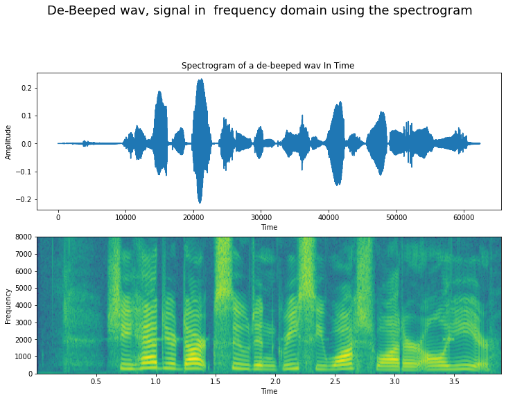

```python
# Plot the De-Beeped signal

plt.figure(figsize = (12,8))
plt.subplot(211)
plt.title('Spectrogram of a de-beeped wav In Time ')
plt.suptitle("de-beeped signal in time domain ", y=1.05, fontsize=18)
plt.plot(recovered_time_signal)
plt.xlabel('Time')
plt.ylabel('Amplitude')

plt.subplot(212)
plt.specgram(recovered_time_signal ,Fs = sr)
plt.suptitle("De-Beeped wav, signal in  frequency domain using the spectrogram ", y=1.05, fontsize=18)
plt.xlabel('Time')
plt.ylabel('Frequency')
plt.show()
```

## **P2: Parallax [5 points]**

```python
!ls $dirpath
```

```
'Cleaned Output.wav'	 december.mat  'HW_1 data'   june.png
'De Beeped Output.wav'	 december.png   june.mat     x.wav
```

```python
june_img = Image.open(dirpath + 'june.png')
december_img = Image.open(dirpath + 'december.png')
```

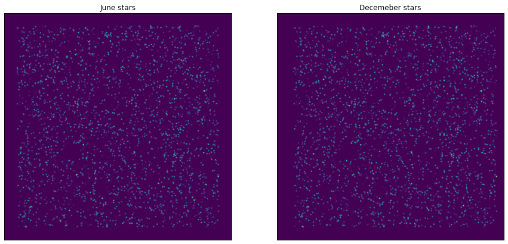

```python
plt.figure(figsize=(15,15))
plt.subplot(1,2,1)
plt.title("June stars")
plt.tick_params(left = False, right = False , labelleft = False ,
                labelbottom = False, bottom = False)
plt.imshow(june_img)


plt.subplot(1,2,2)
# plt.suptitle("December stars capture")
plt.imshow(december_img)
plt.title("Decemeber stars")
plt.tick_params(left = False, right = False , labelleft = False ,
                labelbottom = False, bottom = False)
plt.show()
```

```python
june_mat = scipy.io.loadmat(dirpath+'june.mat')
december_mat = scipy.io.loadmat(dirpath+'december.mat')

print("June keys:" ,june_mat.keys())
print("December keys:" ,december_mat.keys())
```

```
June keys: dict_keys(['__header__', '__version__', '__globals__', 'june'])
December keys: dict_keys(['__header__', '__version__', '__globals__', 'december'])
```

```python
june_data = np.array(june_mat.get('june'))
december_data = np.array(december_mat.get('december'))

print("June data shape: ",june_data.shape)
print("December data shape: ",december_data.shape)
```

```
June data shape:  (2700, 2)
December data shape:  (2700, 2)
```

```python
print("June samples: \n", june_data[:5,:] )
print("\nDecember samples: \n", december_data[:5,:])
```

```
June samples:
 [[1377  974]
 [ 299 1603]
 [ 376  632]
 [1390 1634]
 [1887 1571]]

December samples:
 [[1417  974]
 [ 341 1603]
 [ 418  632]
 [1442 1634]
 [1919 1571]]
```

```python
# disparity = difference between x coordinates of june stars and december stars

disparity = december_data[:, 0] - june_data[:, 0]
disparity.shape
```

```
(2700,)
```

### Histogram of the Disparity matrix

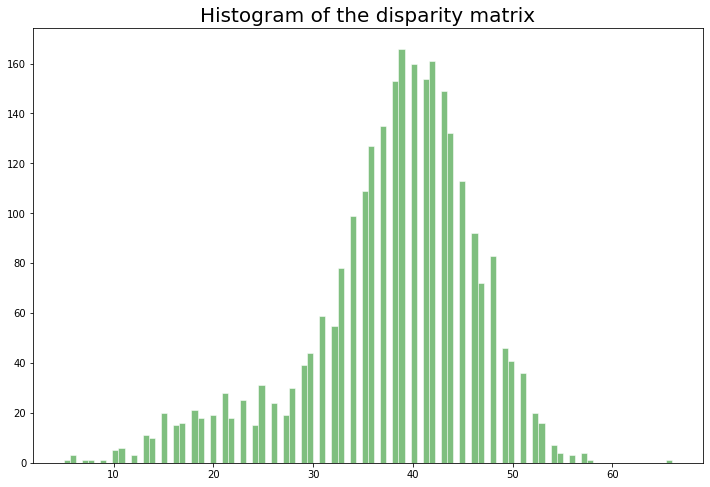

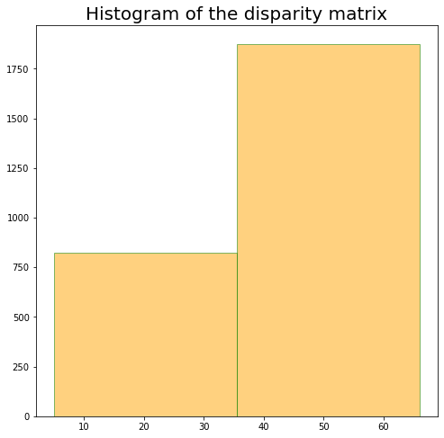

```python
from numpy.core.fromnumeric import size
plt.figure(figsize=(12,8))
plt.hist(disparity,bins= 100, color = 'green', alpha= 0.5,
         histtype='bar', ec='white')
plt.title("Histogram of the disparity matrix", size = 20)
plt.show()

plt.figure(figsize=(8,8))
plt.hist(disparity, bins=2, color='orange', alpha=0.5,
         ec='green')
plt.title("Histogram of the disparity matrix", size = 20)
plt.show()
```

- From the first Histogram we are not able to see the clear distinction of any clusters
- but we can visually see the mix of 2 guassian distribution overlapping eachother
- But when I make 2 bins, we can see that difference is clearly visible but we cannot be sure off

### **K means clustering of the disparity matrix**

```python
disparity_df = pd.DataFrame(disparity, columns=['dist'])
disparity_df.describe()
```

|  | dist |
| --- | --- |
| count | 2700.000000 |
| mean | 37.865556 |
| std | 8.552265 |
| min | 5.000000 |
| 25% | 34.000000 |
| 50% | 39.000000 |
| 75% | 43.000000 |
| max | 66.000000 |

```python
disparity_df
```

|  | dist |
| --- | --- |
| 0 | 40 |
| 1 | 42 |
| 2 | 42 |
| 3 | 52 |
| 4 | 32 |
| ... | ... |
| 2695 | 10 |
| 2696 | 37 |
| 2697 | 37 |
| 2698 | 48 |
| 2699 | 39 |

2700 rows × 1 columns

https://www.analyticsvidhya.com/blog/2021/04/k-means-clustering-simplified-in-python/

```python
# find the euclidian distance between the centroid and the data points
def euclidian_distance(data, mu):
  euc_dist = np.sqrt((data.dist - mu) ** 2)
  return euc_dist

# calculate the mean and assign them as the new centroids
def calc_mean_reassign_centroid(df, centriods_df):
  predicted_cluster_values = df.Centriod_num.unique()
  mu_list = []
  for value in predicted_cluster_values:
    cluster_points = df[df['Centriod_num'] == value]
    cluster_points = cluster_points.loc[:, 'dist']
    mu_list.append(cluster_points.mean(axis=0))
  mu_df = pd.DataFrame(mu_list, columns=['Centriod_mean'])
  return mu_df
```

```python
def k_Means_Clustering(data, number_clusters, max_iter):

    #randomly initiating two cluster centroids
    centriods = np.random.randint(low = int(min(data.dist)),
                                 high = int(max(data.dist)),
                                 size = number_clusters) #.reshape(-1,1)
    centriods_df = pd.DataFrame(centriods, columns=["Centriod_mean"])
    final_centroids = centriods_df.copy()

    cluster_columns = []
    for k in range(number_clusters):
      cluster_columns.append("Cluster_" + str(k))

    for col in cluster_columns:
      data[col] = 0

    is_centroid_unique = True
    iteration_count = 0

    while iteration_count < max_iter and is_centroid_unique is True:
      for col in range(centriods_df.shape[0]):
        col_name = "Cluster_" + str(col)
        data[col_name] = euclidian_distance(data, centriods_df.Centriod_mean[col])
      print(centriods_df.Centriod_mean.tolist())
      cluster_dist_df = data[cluster_columns]
      data['Centriod_id'] = cluster_dist_df.idxmin(axis=1)
      data['Centriod_num'] = 0
      clust_num = []
      for m in range(data.shape[0]):
        clust_num.append(cluster_columns.index(data.iloc[m]['Centriod_id']))

      data['Centriod_num'] = clust_num

      iteration_count +=1

      # Comparing the old and new centroid points
      centriods_df_new = calc_mean_reassign_centroid(data, centriods_df)
      if centriods_df.equals(centriods_df_new):
            is_centroid_unique = False
            final_centroids = centriods_df_new
      else:
          centriods_df = centriods_df_new

    return data, final_centroids, cluster_columns
```

```python
data, final_centroids, clus = k_Means_Clustering(disparity_df, 2, 100)
```

```
[32, 25]
[40.34421364985163, 20.718475073313783]
[40.738576449912124, 22.443396226415093]
[40.997744700045104, 23.488612836438925]
[41.22664199814986, 24.358736059479554]
```

```python
data.head(10)
```

|  | dist | Cluster_0 | Cluster_1 | Centriod_id | Centriod_num |
| --- | --- | --- | --- | --- | --- |
| 0 | 40 | 1.226642 | 15.641264 | Cluster_0 | 0 |
| 1 | 42 | 0.773358 | 17.641264 | Cluster_0 | 0 |
| 2 | 42 | 0.773358 | 17.641264 | Cluster_0 | 0 |
| 3 | 52 | 10.773358 | 27.641264 | Cluster_0 | 0 |
| 4 | 32 | 9.226642 | 7.641264 | Cluster_1 | 1 |
| 5 | 23 | 18.226642 | 1.358736 | Cluster_1 | 1 |
| 6 | 35 | 6.226642 | 10.641264 | Cluster_0 | 0 |
| 7 | 38 | 3.226642 | 13.641264 | Cluster_0 | 0 |
| 8 | 45 | 3.773358 | 20.641264 | Cluster_0 | 0 |
| 9 | 41 | 0.226642 | 16.641264 | Cluster_0 | 0 |

```python
print(clus)
final_centroids
```

```
['Cluster_0', 'Cluster_1']
```

|  | Centriod_mean |
| --- | --- |
| 0 | 41.226642 |
| 1 | 24.358736 |

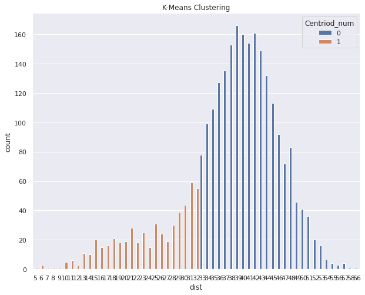

```python
sns.set(rc={'figure.figsize':(10,8)})
sns.countplot(data['dist'], hue = data['Centriod_num']).set_title("K-Means Clustering")
plt.show()
```

### **The Final Centriods are :**

```python
final_centroids
```

|  | Centriod_mean |
| --- | --- |
| 0 | 41.226642 |
| 1 | 24.358736 |

## **P3: GMM for Parallax [5 points]**

**References for Problem 3, EM algorithm for GMM**

- https://towardsdatascience.com/how-to-code-gaussian-mixture-models-from-scratch-in-python-9e7975df5252
- https://towardsdatascience.com/gaussian-mixture-models-implemented-from-scratch-1857e40ea566
- https://en.wikipedia.org/wiki/Expectation%E2%80%93maximization_algorithm

Before we start running EM, we need to give initial values for the learnable parameters. We can guess the values for the means and variances, and initialize the weight parameters as 1/k.

In the E step, we calculate the likelihood of each observation xᵢ using the estimated parameters.

$$ f\left(\mathbf{x} \mid \mu_{k}, \sigma_{k}^{2}\right)=\frac{1}{\sqrt{2 \pi \sigma_{k}^{2}}} \exp \left(-\frac{\left(\mathbf{x}-\mu_{k}\right)^{2}}{2 \sigma_{k}^{2}}\right) $$

```python
def pdf_guassian_distribution(data, mean, variance):
# def pdf_guassian_distribution(data, mean, variance):
  # A normal continuous random variable.
  s1 = float(1/(np.sqrt(2*np.pi*variance)))
  s2 = np.exp(-(np.square(data - mean)/(2*variance)))
  return s1 * s2
```

```python
mu1 = np.mean(disparity)
sigma1 = np.var(disparity)

pdf_guassian_distribution(disparity, mu1, sigma1)
```

```
array([0.045225  , 0.04150894, 0.04150894, ..., 0.04641777, 0.02311384,
       0.04624738])
```

### **Guassian representation of the Disparity Data**

```
[]
```

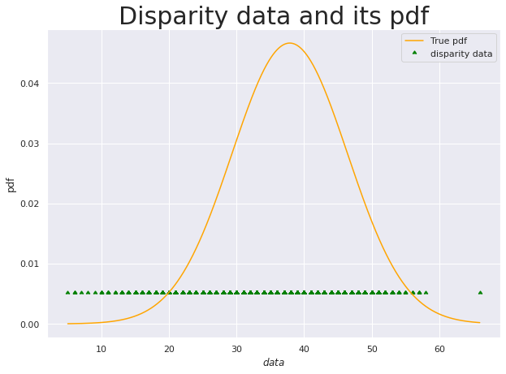

```python
# visualize the training data
bins = np.linspace(np.min(disparity),np.max(disparity),len(disparity))

plt.figure(figsize=(10,7))
plt.xlabel("$data $")
plt.ylabel("pdf")
plt.scatter(disparity, [0.005] * len(disparity), color='green', s=20, marker=10, label="disparity data")
plt.plot(bins, pdf_guassian_distribution(bins, mu1, sigma1), color='orange', label="True pdf")
plt.legend()
plt.title("Disparity data and its pdf", size = 30)
plt.plot()
```

**Then, we can calculate the likelihood of a given example xᵢ to belong to the kᵗʰ cluster**

$$ \mathbf{b}_{k}=\frac{f\left(\mathbf{x} \mid \mu_{k}, \sigma_{k}^{2}\right) \phi_{k}}{\sum_{k=1}^{K} f\left(\mathbf{x} \mid \mu_{k}, \sigma_{k}^{2}\right) \phi_{k}} $$

Using Bayes Theorem, we get the posterior probability of the kth Gaussian to explain the data. That is the likelihood that the observation xᵢ was generated by kᵗʰ Gaussian. Note that the parameters Φ act as our prior beliefs that an example was drawn from one of the Gaussians we are modeling.

**Then, in the maximization, or M step, we re-estimate our learning parameters as follows** $$ \mu_{k}=\frac{\sum \mathbf{b}_{k} \mathbf{x}}{\sum \mathbf{b}_{k}} \quad \sigma_{k}^{2}=\frac{\sum \mathbf{b}_{k}\left(\mathbf{x}-\mu_{k}\right)^{2}}{\sum \mathbf{b}_{k}} \quad \phi_{k}=\frac{1}{N} \sum \mathbf{b}_{k} $$

we update the mean (μₖ), variance (σ₂²), and the scaling parameters Φₖ.

```python
def pdf_dist_normal(mu, variance, x):
  return (1/np.sqrt(2*np.pi*(variance))) * (np.exp(-(((x-mu)**2)/(2*variance))))
```

```python
def expectation_maximization(data, num_clusters, max_iter, tolerance):
    # This will serve initially the prior probabilities to calculate the weight
    # of each data point belonging to a particular cluster
    # we can use our prior knowledge about the problem we are trying to colve
    prob_A, prob_B = 0.1, 0.9

    #Using the centroids found using k-means clustering
    mean_A, mean_B = 27.743, 42.312
    var_A, var_B = 0.15, 0.75

    iter_count = 0

    while iter_count <= max_iter:
        probX_given_A = pdf_dist_normal(mean_A, var_A, data)
        probX_given_B = pdf_dist_normal(mean_B, var_B, data)
        probX_given_A[probX_given_A == 0] = 0.05
        probX_given_B[probX_given_B == 0] = 0.05

        #E-step
        likelihood_A = (prob_A * probX_given_A)/((prob_A * probX_given_A) + (prob_B * probX_given_B))
        likelihood_B = (prob_B * probX_given_B)/((prob_A * probX_given_A) + (prob_B * probX_given_B))

        prev_mean_A, prev_mean_B = mean_A, mean_B

        #M-step
        mean_A = np.sum(likelihood_A * data)/np.sum(likelihood_A)
        mean_B = np.sum(likelihood_B * data)/np.sum(likelihood_B)

        var_A = np.sum(likelihood_A * (data - mean_A) * (data - mean_A))/np.sum(likelihood_A)
        var_B = np.sum(likelihood_B * (data - mean_B) * (data - mean_B))/np.sum(likelihood_B)

        iter_count += 1

        if np.abs(mean_A - prev_mean_A) < tolerance and np.abs(mean_B - prev_mean_B) < tolerance:
            break

    likelihood_AB = np.concatenate((likelihood_A, likelihood_B), axis = 1)
    clust_id = np.argmax((likelihood_AB), axis = 1)
    final_df = pd.DataFrame(data, columns= ['Disparity Data'])
    final_df['Cluster'] = clust_id

    return mean_A, mean_B, final_df
```

```python
mean_A, mean_B, final_df = expectation_maximization(disparity.reshape(-1,1), 2, 100, 0.0001)
```

**Centriod values calculated by Expectation Maximization Algorithm**  
**Centriod A = 19.985**  
**Centriod B = 40.0027**

```python
print("Expectation Maximixation algo means are :", np.round(mean_A,4), np.round(mean_B,4))
```

```
Expectation Maximixation algo means are : 19.985 40.0027
```

```python
final_df
```

|  | Disparity Data | Cluster |
| --- | --- | --- |
| 0 | 40 | 1 |
| 1 | 42 | 1 |
| 2 | 42 | 1 |
| 3 | 52 | 1 |
| 4 | 32 | 1 |
| ... | ... | ... |
| 2695 | 10 | 0 |
| 2696 | 37 | 1 |
| 2697 | 37 | 1 |
| 2698 | 48 | 1 |
| 2699 | 39 | 1 |

2700 rows × 2 columns

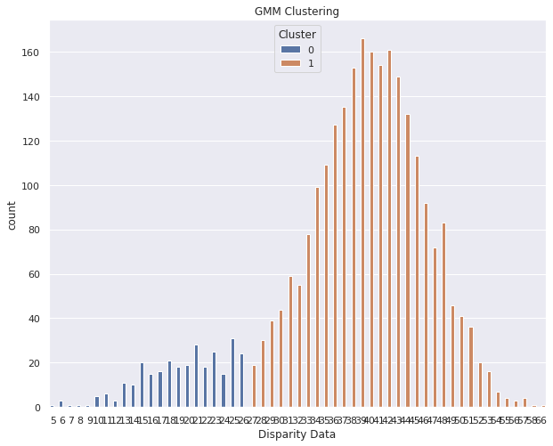

```python
sns.countplot(final_df['Disparity Data'], hue = final_df['Cluster']).set_title("GMM Clustering")
plt.show()
```

## Final: Convert the notebook to HTML

```python
%%shell
jupyter nbconvert --to html /content/AG_MLSP_SP22_HW_2.ipynb
```

```
[NbConvertApp] Converting notebook /content/AG_MLSP_SP22_HW_2.ipynb to html
[NbConvertApp] Writing 2082423 bytes to /content/AG_MLSP_SP22_HW_2.html
```